# Assignment 2 - Summer 2025

Author

**1. Consider a sample of data from the [Jackson Heart Study](https://www.jacksonheartstudy.org/). In this problem, we will be examining body mass index (*BMI*; kg/m<sup>2</sup>) as a function of health as categorized by physical activity (*PA3cat*: Ideal Health, Intermediate Health, and Poor Health).**

**1a. Find the summary statistics for BMI across the categories of physical activity (*PA3cat*).**

```r
jackson_heart %>% group_by(PA3cat) %>% mean_median(BMI)
```

```
# A tibble: 3 × 4
  PA3cat              variable mean_sd    median_iqr
  <fct>               <chr>    <chr>      <chr>
1 Ideal Health        BMI      30.9 (6.6) 29.8 (7.6)
2 Intermediate Health BMI      31.7 (6.8) 30.7 (8.0)
3 Poor Health         BMI      32.4 (7.2) 31.3 (9.3)
```

**1b. Construct the appropriate one-way ANOVA table to model BMI (*BMI*) as a function of physical activity (*PA3cat*).**

```r
jackson_heart %>% one_way_ANOVA_table(continuous = BMI,
                                      grouping = PA3cat)
```

One-Way ANOVA Table

| **Source** | **Sum of Squares** | *df* | **Mean Squares** | *F* |
| --- | --- | --- | --- | --- |
| Treatment | 809.36 | 2 | 404.68 | 8.36 |
| Error | 127,643.84 | 2,638 | 48.39 |  |
| Total | 128,453.20 | 2,640 |  |  |

**1c. Use ANOVA to determine if there is a difference in BMI (*BMI*) among the levels of physical activity (*PA3cat*). Test at the $\alpha=0.01$ level.**

```r
jackson_heart %>% one_way_ANOVA(continuous = BMI,
                                grouping = PA3cat,
                                alpha = 0.01)
```

```
One-Way ANOVA:
H₀: μ_Ideal Health = μ_Intermediate Health = μ_Poor Health
H₁: At least one group mean is different
Test Statistic: F(2, 2638) = 8.364
p-value: p < 0.001
Conclusion: Reject the null hypothesis (p = < 0.001 < α = 0.01)
```

Remember to typeset your results!

**1d. Use the Kruskal-Wallis to determine if there is a difference in BMI (*BMI*) between the three levels of health as categorized by physical activity (*PA3cat*). Test at the $\alpha=0.01$ level.**

```r
jackson_heart %>% kruskal_HT(continuous = BMI,
                             grouping = PA3cat,
                             alpha = 0.01)
```

```
Kruskal–Wallis Rank-Sum Test

H₀: M_Ideal Health = M_Intermediate Health = M_Poor Health
H₁: At least one group is different

Test Statistic: X(2) = 18.943,
 p < 0.001
Conclusion: Reject the null hypothesis (p = < 0.001 < α = 0.01)
```

Remember to typeset your results!

**1e. Check the ANOVA assumptions graphically.**

```r
jackson_heart %>% ANOVA_assumptions(continuous = BMI,
                                    grouping = PA3cat)
```

[output not shown]

[output not shown]

**1f. If necessary, formally test for the variance assumption. Test at the $\alpha=0.01$ level. If you do not feel this step necessary, explain why. (Please don’t overthink the explanation - think of it as a note to us. :))**

```r
jackson_heart %>% variances_HT(continuous = BMI,
                               grouping = PA3cat,
                               alpha = 0.01)
```

```
Brown-Forsythe-Levene test for equality of variances:
Null: σ²_Poor Health = σ²_Intermediate Health = σ²_Ideal Health
Alternative: At least one variance is different
Test statistic: F(2,2638) = 4.695
p-value: p = 0.009
Conclusion: Reject the null hypothesis (p = 0.0092 < α = 0.01)
```

Remember to typeset your results!

**1g. Draw conclusions based on your observations. (Do we meet the assumption?)**

**1h. Based on your responses in (1g), which test’s result are you going to present to the lead scientist at the JHS? (Hint: you will pick either the analysis (1c) or (1d)).**

**1i. Perform the appropriate (based on your response in (1h)) posthoc test to determine which pairwise differences exist between the three groups. Test at the $\alpha=0.01$ level; because this is a large cohort study, we should treat this as a confirmatory analysis.**

- If student says we should present ANOVA (regardless of correctness):

```r
jackson_heart %>% posthoc_tukey(continuous = BMI,
                                grouping = PA3cat)
```

```
                        comparison Mean Diff. p-value
1 Intermediate Health-Ideal Health       0.76   0.108
2         Poor Health-Ideal Health       1.44 < 0.001
3  Poor Health-Intermediate Health       0.67   0.074
```

- If student says we should present Kruskal-Wallis (regardless of correctness):

```r
jackson_heart %>% posthoc_dunn(continuous = BMI,
                               grouping = PA3cat,
                               adjust = TRUE)
```

```
                          Comparison         Z     p
1 Ideal Health - Intermediate Health -2.198475 0.084
2         Ideal Health - Poor Health -4.282431 0.000
3  Intermediate Health - Poor Health -2.276284 0.068
```

Make sure that you state the resulting pairwise differences.

**1j. Write a brief paragraph to describe your analysis results. You have enough information to discuss the results of analysis (1c or 1d) using the summary statistics you computed in (1a) and the posthoc test results in (1i).**

**2. Again, consider the sample of data from the JHS. In this problem, we will be examining systolic blood pressure (*sbp*; mmHg) as a function of health as categorized by body mass index (*BMI3cat*), smoking status (*everSmoker*), and the interaction between health as categorized by body mass index and smoking status.**

**2a. Find the summary statistics for systolic blood pressure (*sbp*) across the categories of body mass index (*BMI3cat*).**

```r
jackson_heart %>% group_by(BMI3cat) %>% mean_median(sbp)
```

```
# A tibble: 3 × 4
  BMI3cat             variable mean_sd      median_iqr
  <fct>               <chr>    <chr>        <chr>
1 Ideal Health        sbp      123.6 (16.6) 121.1 (21.1)
2 Intermediate Health sbp      125.6 (15.4) 123.8 (20.2)
3 Poor Health         sbp      127.0 (15.3) 125.7 (18.3)
```

**2b. Find the summary statistics for systolic blood pressure (*sbp*) across the categories of smoking status (*everSmoker*).**

```r
jackson_heart %>% group_by(everSmoker) %>% mean_median(sbp)
```

```
# A tibble: 2 × 4
  everSmoker variable mean_sd      median_iqr
  <fct>      <chr>    <chr>        <chr>
1 No         sbp      125.7 (15.3) 123.8 (19.3)
2 Yes        sbp      127.0 (16.1) 124.8 (19.3)
```

**2c. Find the summary statistics for systolic blood pressure (*sbp*) across the categories of body mass index (*BMI3cat*) and the categories of smoking status (*everSmoker*).**

```r
jackson_heart %>% group_by(BMI3cat, everSmoker) %>% mean_median(sbp)
```

```
# A tibble: 6 × 5
  BMI3cat             everSmoker variable mean_sd      median_iqr
  <fct>               <fct>      <chr>    <chr>        <chr>
1 Ideal Health        No         sbp      121.4 (15.0) 119.2 (19.5)
2 Ideal Health        Yes        sbp      127.0 (18.5) 124.8 (24.3)
3 Intermediate Health No         sbp      125.0 (14.8) 122.9 (20.2)
4 Intermediate Health Yes        sbp      126.8 (16.6) 123.8 (21.5)
5 Poor Health         No         sbp      127.0 (15.5) 125.7 (18.3)
6 Poor Health         Yes        sbp      127.1 (14.9) 125.2 (17.4)
```

**2d. Construct the appropriate two-way ANOVA table to model systolic blood pressure (*sbp*; mmHg) as a function of health as categorized by body mass index (*BMI3cat*), smoking status (*everSmoker*), and the interaction between health as categorized by body mass index and smoking status.**

```r
jackson_heart %>% two_way_ANOVA_table(continuous = sbp,
                                      A = BMI3cat,
                                      B = everSmoker,
                                      interaction = TRUE)
```

Two-Way ANOVA Table

| **Source** | **Sum of Squares** | *df* | **Mean Squares** | *F* | *p* |
| --- | --- | --- | --- | --- | --- |
| Regression | 6839.53 | 5 |  |  |  |
| •BMI3cat | 3619.33 | 2 | 1809.67 | 7.55 | < 0.001 |
| •everSmoker | 1300.07 | 1 | 1300.07 | 5.42 | 0.020 |
| •Interaction | 1920.13 | 2 | 960.06 | 4.00 | 0.018 |
| Error | 631911.65 | 2635 | 239.81 |  |  |
| Total | 638751.18 | 2640 |  |  |  |

**2e. Use the appropriate hypothesis test to show that there is not a significant interaction between body mass index category (*BMI3cat*) and smoking status (*everSmoker*) at the $\alpha=0.01$ level.**

```r
jackson_heart %>% two_way_ANOVA(continuous = sbp,
                                A = BMI3cat,
                                B = everSmoker,
                                interaction = TRUE,
                                alpha = 0.01)
```

```
Test for Interaction (BMI3cat × everSmoker):

H₀: The relationship between sbp and BMI3cat does not depend on everSmoker.
H₁: The relationship between sbp and BMI3cat depends on everSmoker.
Test Statistic: F(2, 2635) = 4
p-value: p = 0.018
Conclusion: Fail to reject the null hypothesis (p = 0.0184 ≥ α = 0.01)
```

Remember to typeset your results!

**2f. Reconstruct the two-way ANOVA table without the interaction.**

```r
jackson_heart %>% two_way_ANOVA_table(continuous = sbp,
                                      A = BMI3cat,
                                      B = everSmoker,
                                      interaction = FALSE)
```

Two-Way ANOVA Table

| **Source** | **Sum of Squares** | *df* | **Mean Squares** | *F* | *p* |
| --- | --- | --- | --- | --- | --- |
| Regression | 4919.40 | 3 |  |  |  |
| •BMI3cat | 3619.33 | 2 | 1809.67 | 7.53 | < 0.001 |
| •everSmoker | 1300.07 | 1 | 1300.07 | 5.41 | 0.020 |
| Error | 633831.78 | 2637 | 240.36 |  |  |
| Total | 638751.18 | 2640 |  |  |  |

**2g. Use the appropriate hypothesis test to determine if there a main effect of smoking status (*everSmoker*). Test at the $\alpha=0.01$ level.**

```r
jackson_heart %>% two_way_ANOVA(continuous = sbp,
                                A = BMI3cat,
                                B = everSmoker,
                                interaction = FALSE,
                                alpha = 0.01)
```

```
Test for Main Effect BMI3cat:

H₀: μ_Ideal Health = μ_Intermediate Health = μ_Poor Health
H₁: At least one mean is different.
Test Statistic: F(2, 2637) = 7.53
p-value: p = < 0.001
Conclusion: Reject the null hypothesis (p = < 0.001 < α = 0.01)

Test for Main Effect everSmoker:

H₀: μ_No = μ_Yes
H₁: At least one mean is different.
Test Statistic: F(1, 2637) = 5.41
p-value: p = 0.020
Conclusion: Fail to reject the null hypothesis (p = 0.0201 ≥ α = 0.01)
```

Remember to typeset your results!

**2h. Use the appropriate hypothesis test to determine if there a main effect of body mass index categorization (*BMI3cat*). Test at the $\alpha=0.01$ level.**

```r
jackson_heart %>% two_way_ANOVA(continuous = sbp,
                                A = BMI3cat,
                                B = everSmoker,
                                interaction = FALSE,
                                alpha = 0.01)
```

```
Test for Main Effect BMI3cat:

H₀: μ_Ideal Health = μ_Intermediate Health = μ_Poor Health
H₁: At least one mean is different.
Test Statistic: F(2, 2637) = 7.53
p-value: p = < 0.001
Conclusion: Reject the null hypothesis (p = < 0.001 < α = 0.01)

Test for Main Effect everSmoker:

H₀: μ_No = μ_Yes
H₁: At least one mean is different.
Test Statistic: F(1, 2637) = 5.41
p-value: p = 0.020
Conclusion: Fail to reject the null hypothesis (p = 0.0201 ≥ α = 0.01)
```

Remember to typeset your results!

**2i. Construct the appropriate profile plot for this analysis.**

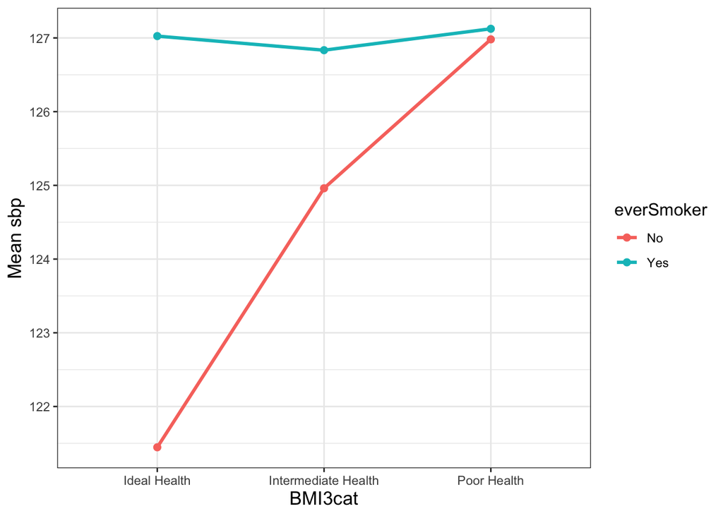

```r
jackson_heart %>% profile_plot(continuous = sbp,
                               xaxis = BMI3cat,
                               lines = everSmoker)
```

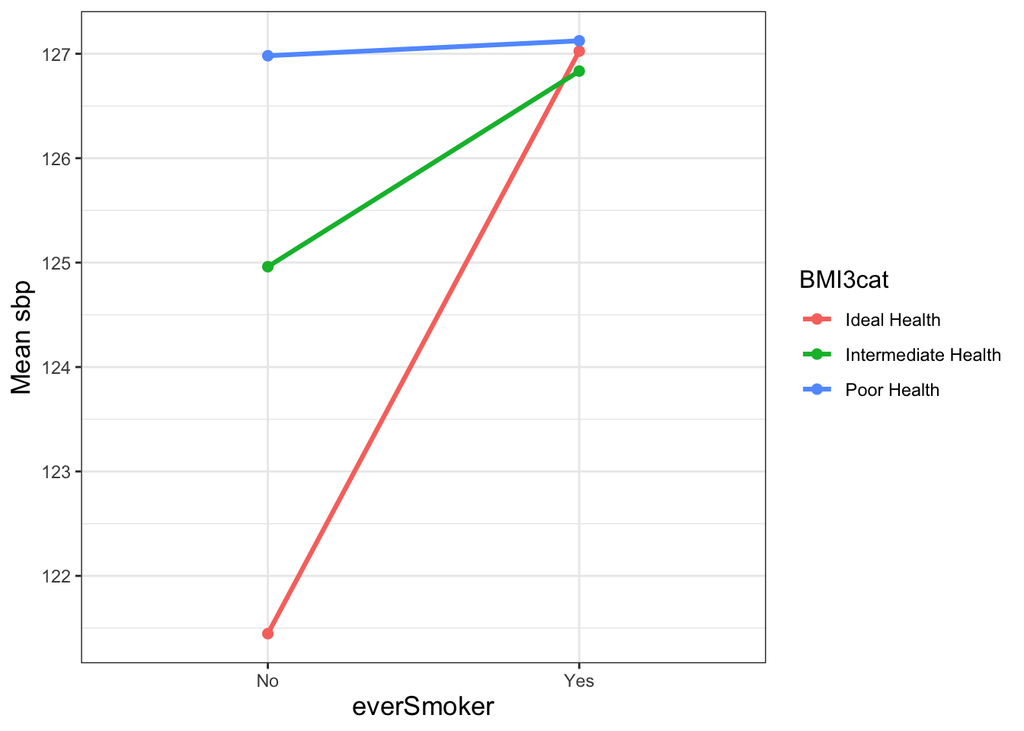

```r
jackson_heart %>% profile_plot(continuous = sbp,
                               xaxis = everSmoker,
                               lines = BMI3cat)
```

**2k. Graphically assess the ANOVA assumptions.**

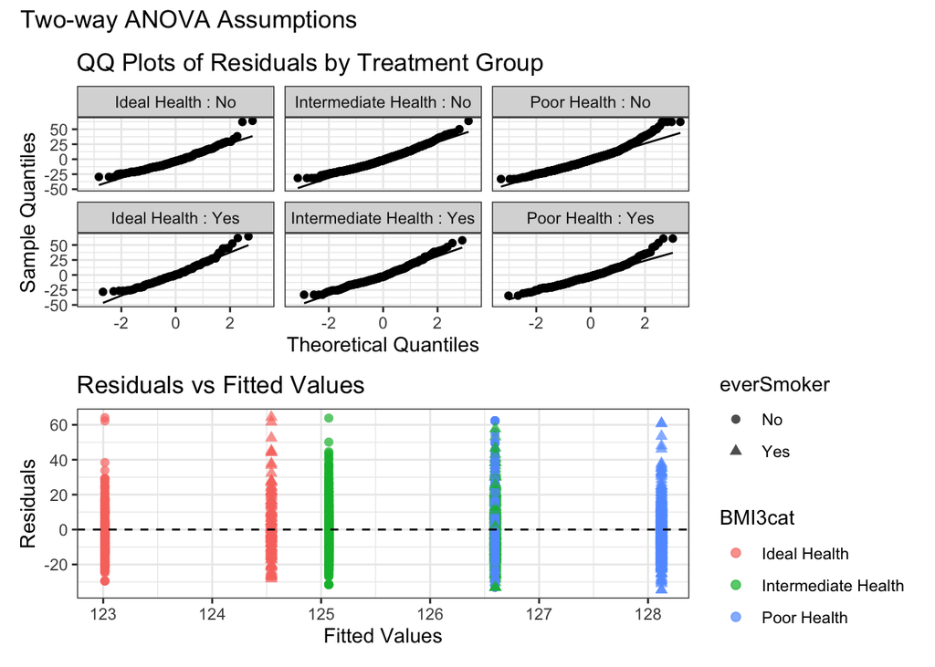

```r
jackson_heart %>% ANOVA2_assumptions(continuous = sbp,
                                     A = BMI3cat,
                                     B = everSmoker,
                                     interaction = FALSE)
```

**2l. Using the graphs in (2k), determine if our analysis is valid. Explain why it is valid or why it is not valid.**